# Generate data from a model

```r
# libraries
library(simts)
library(gmwmx)
```

```r
phase =     0.45
amplitude = 2.5
sigma2_wn =       15
sigma2_powerlaw = 10
d =               0.4
bias =            0
trend =           5/365.25
cosU =            amplitude*cos(phase)
sinU =            amplitude*sin(phase)
```

Let us consider a period of 5 year with daily observations:

```r
n = 5*365
```

Using functions implemented in `simts`, we generate realizations from the sum of a White noise and PowerLaw process.

Note that the functions that enable to generate stochastic models that include Power Law process, Matèrn process or Fractional Gaussian noise are (for now) only available from the development version of the package `simts` that can be easily installed with:

```r
install.packages("devtools")
devtools::install_github("SMAC-Group/simts")
```

```r
model_i = WN(sigma2 = sigma2_wn) + PLP(sigma2 = sigma2_powerlaw, d = d)
```

```r
# define time at which there are jumps
jump_vec =  c(600, 1200)
jump_height = c(20, 30)

# define myseed
myseed=123
```

We generate residuals from the stochastic model

```r
# generate residuals
eps = simts::gen_gts(model = model_i, n= n)
```

Using function `create_A_matrix()`, we encode the intercept, a deterministic vector (trend) and sinusoidal signals in a matrix $\boldsymbol{A}$ in order to compute the deterministic component of the signal in a linear fashion. Similarly, we define the vector of fixed coefficients denoted by $\boldsymbol{x}_0$ in the paper.

```r
# add trend and sin
A = gmwmx::create_A_matrix(t_nogap = 1:length(eps), n_seasonal =  1, jumps = NULL)

# define beta
x_0 = c(bias, trend,  cosU,  sinU)

# create time series
deterministic_signal = A %*% x_0
```

We can graphically represent the functional and stochastic component of the model as follows

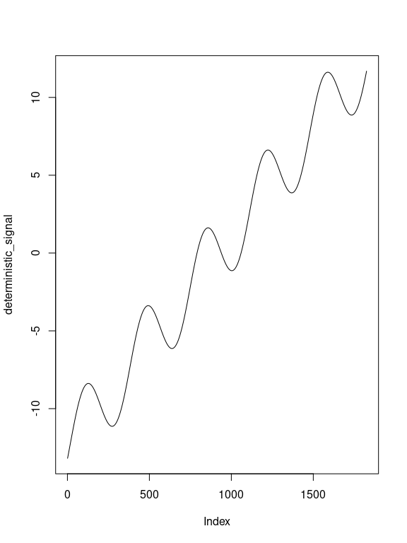

```r
plot(deterministic_signal, type="l")
```

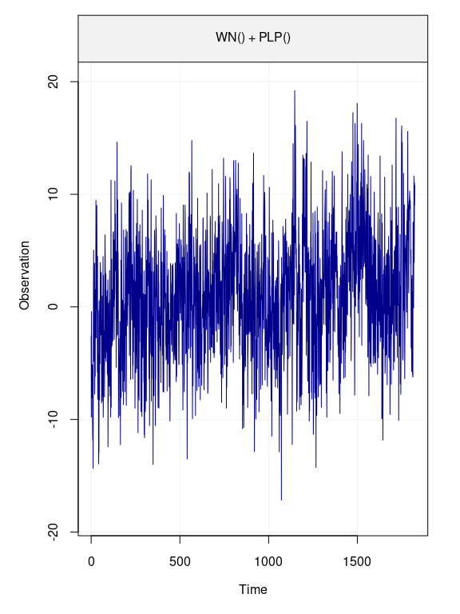

```r
plot(eps)
```

We can add location shifts (jumps) in the signal as such:

```r
# add trend, gaps and sin
A = gmwmx::create_A_matrix(t_nogap = 1:length(eps), n_seasonal =  1, jumps = jump_vec)

# define beta
x_0 = c(bias, trend,  cosU,  sinU, jump_height)

# create time series
deterministic_signal = A %*% x_0
```

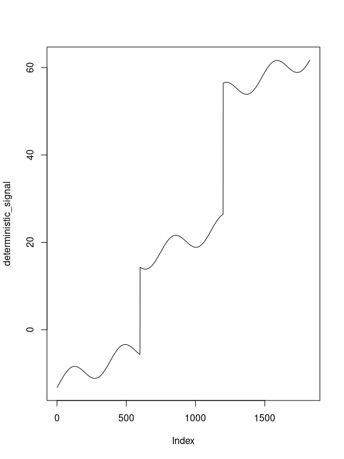

```r
plot(deterministic_signal, type="l")
```

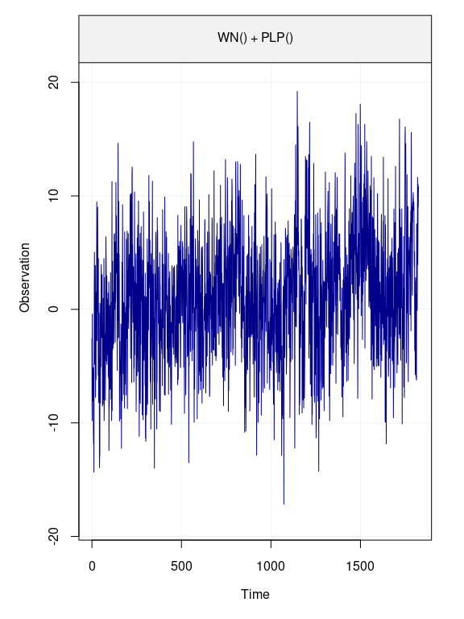

```r
plot(eps)
```

We can then define and plot the generated time series

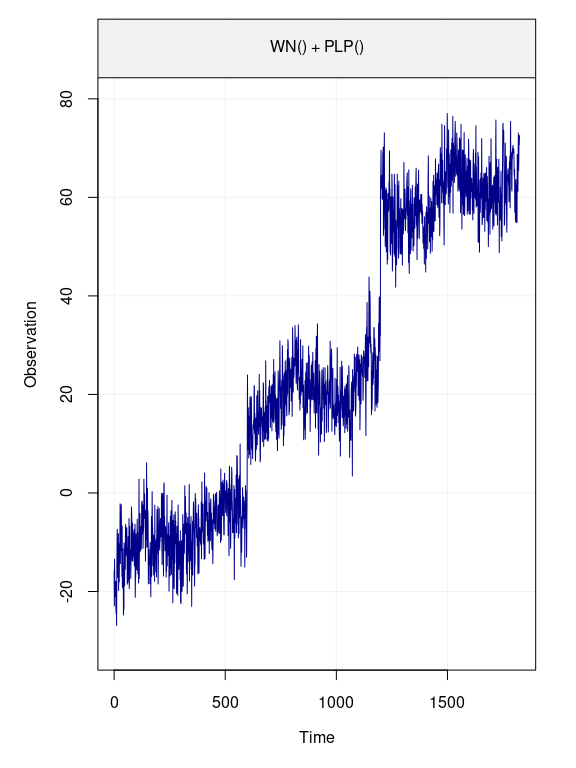

```r
yy = deterministic_signal + eps
plot(yy)
```

We define a `gnssts` object.

```r
# save signal in temp
gnssts_obj = create.gnssts(t = 1:length(yy), y = yy, jumps = jump_vec)
```

```r
class(gnssts_obj)
```

```
#> [1] "gnssts"
```

We can save a `gnssts` object as a `.mom` file with the function `write.gnssts()`

```r
write.gnssts(gnssts_obj, filename = "simulated_data.mom")
```

The saved `.mom` file will have the following structure:

[output not shown]

```r
fit_gmwmx = gmwmx::estimate_gmwmx(x = gnssts_obj,
                                  model_string = "wn+powerlaw",
                                  n_seasonal = 1,
                                  theta_0 = c(0.1, 0.1, 0.1),
                                  k_iter = 1)

fit_gmwmx
```

```
#> GNSS time series model
#>
#>  * Model: wn + powerlaw
#>
#>  * Functional parameters:
#>      bias            :  +0.778520
#>      trend           :  +0.015804
#>      A*cos(U)        :  +2.366464
#>      A*sin(U)        :  +1.958204
#>      jump            : +20.061620
#>      jump            : +30.596085
#>
#>  * Stochastic parameters:
#>      wn_sigma2                      :    +11.80775096
#>      powerlaw_sigma2                :    +11.93347935
#>      powerlaw_d                     :     +0.34017417
#>
#>  * Estimation time: 0.14 s
```

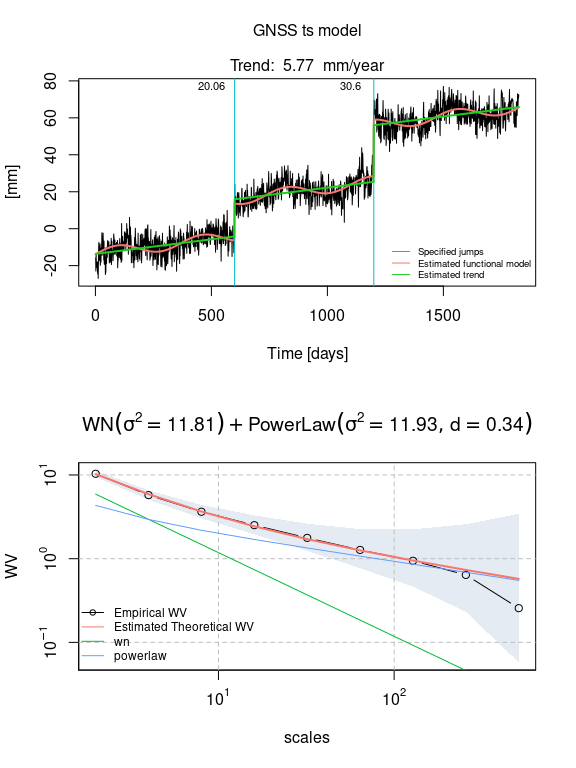

```r
plot(fit_gmwmx)
```

```r
fit_gmwmx_2 = gmwmx::estimate_gmwmx(x = gnssts_obj,
                                    model_string = "wn+powerlaw",
                                    n_seasonal = 1,
                                    theta_0 = c(0.1, 0.1, 0.1),
                                    k_iter = 2)

fit_gmwmx_2
```

```
#> GNSS time series model
#>
#>  * Model: wn + powerlaw
#>
#>  * Functional parameters:
#>      bias            :  +0.891683
#>      trend           :  +0.016483
#>      A*cos(U)        :  +2.438139
#>      A*sin(U)        :  +2.043069
#>      jump            : +19.550541
#>      jump            : +30.869573
#>
#>  * Stochastic parameters:
#>      wn_sigma2                      :    +11.96947053
#>      powerlaw_sigma2                :    +11.75061286
#>      powerlaw_d                     :     +0.34298983
#>
#>  * Estimation time: 0.39 s
```

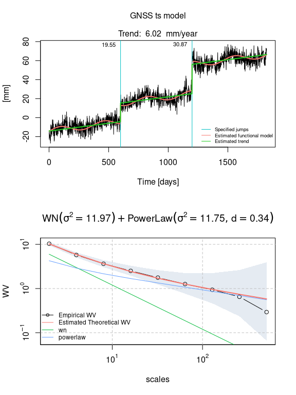

```r
plot(fit_gmwmx_2)
```

```r
fit_mle_hector = gmwmx::estimate_hector(x = gnssts_obj,
                                    model_string = "wn+powerlaw",
                                    n_seasonal = 1
                                    )
```

```r
fit_mle_hector
```

```
#> GNSS time series model
#>
#>  * Model: wn + powerlaw
#>
#>  * Functional parameters:
#>      bias            :  -0.889000 +/- 1.5900000000
#>      trend           :  +0.015639 +/- 0.0019873265
#>      A*cos(U)        :  +2.542700 +/- 0.4870740000
#>      A*sin(U)        :  +0.966218 +/- 0.4826000000
#>      jump            : +18.008400 +/- 1.5199300000
#>      jump            : +30.626100 +/- 1.5310600000
#>
#>  * Stochastic parameters:
#>      wn_sigma2                      :     +9.10561714
#>      powerlaw_sigma2                :    +17.73165228
#>      powerlaw_d                     :     +0.29703100
#>
#>  * Estimation time: 20.17 s
```

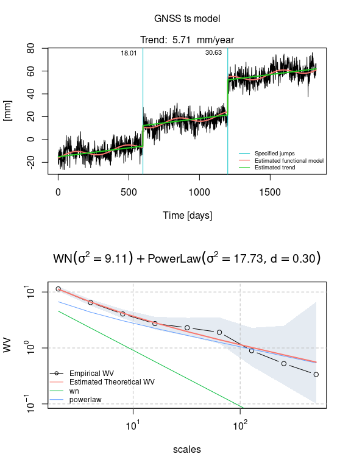

```r
plot(fit_mle_hector)
```